# Phase 2 - HackBio Data Contest

Tasneem Juzer

### This document contains exploratory data analysis results and their codes for the task given for phase 2 of the HackBio Data Contest.

## Decoding and Understanding the dataset

```r
#Read the data
sample <- read.table("sample.tsv", header=TRUE)

#Gives us the basic statistical info. Based on the summary statistics, median, minimum, maximum and mean were found for all numerical columns especially for MAS, Sample Size and P value.
summary(sample)
```

```
##     SNPID               RSID                CHR              POS
##  Length:25000       Length:25000       Min.   : 1.000   Min.   :    67365
##  Class :character   Class :character   1st Qu.: 4.000   1st Qu.: 31819538
##  Mode  :character   Mode  :character   Median : 8.000   Median : 71068010
##                                        Mean   : 8.571   Mean   : 79495862
##                                        3rd Qu.:13.000   3rd Qu.:115694815
##                                        Max.   :22.000   Max.   :249222450
##
##  EFFECT_ALLELE      OTHER_ALLELE       EFFECT_ALLELE_FREQ      BETA
##  Length:25000       Length:25000       Min.   :0.0000     Min.   :-1.53806
##  Class :character   Class :character   1st Qu.:0.0919     1st Qu.:-0.00539
##  Mode  :character   Mode  :character   Median :0.2670     Median :-0.00005
##                                        Mean   :0.3389     Mean   : 0.00030
##                                        3rd Qu.:0.5470     3rd Qu.: 0.00515
##                                        Max.   :1.0000     Max.   : 1.93485
##                                                           NA's   :194
##        SE                P                N             ANCESTRY
##  Min.   :0.00104   Min.   :0.0000   Min.   :    482   Length:25000
##  1st Qu.:0.00358   1st Qu.:0.1163   1st Qu.:  46408   Class :character
##  Median :0.00654   Median :0.3729   Median : 100692   Mode  :character
##  Mean   :0.01802   Mean   :0.4087   Mean   : 374821
##  3rd Qu.:0.00944   3rd Qu.:0.6742   3rd Qu.: 264725
##  Max.   :1.07000   Max.   :0.9999   Max.   :1597374
##  NA's   :194       NA's   :194
```

```r
# unique super populations present (Ancestrors)
print(superpopulations <- unique(sample$ANCESTRY))
```

```
## [1] "AFRICAN"    "EUROPEAN"   "SOUTH_ASIA" "EAST_ASIA"  "HISPANIC"
```

```r
#find how many chromosomes are present
unique(sample$CHR)
```

```
##  [1]  1  2  3  4  5  6  7  8  9 10 11 12 13 14 15 16 17 18 19 20 21 22
```

```r
# find if NA values present in our sample
print(colSums(is.na(sample)))
```

```
##              SNPID               RSID                CHR                POS
##                  0                  0                  0                  0
##      EFFECT_ALLELE       OTHER_ALLELE EFFECT_ALLELE_FREQ               BETA
##                  0                  0                  0                194
##                 SE                  P                  N           ANCESTRY
##                194                194                  0                  0
```

## Number of significant SNPs in the total population and even across individual populations

### For answering the first question given in the task, “How many SNPs are significant (p-value < 0.01) for variability in height (MAF > 0.01) in all the super populations” , the following code and plots conveys the answer.

```r
data_color <- c("red", "blue", "green", "yellow", "purple")

# Filter data-  p-value < 0.01 and MAF > 0.01 for each super population
significant_snps <- data.frame()

for (sp in superpopulations) {
  subset_data <- sample[sample$ANCESTRY == sp, ]

  # Filter SNPs based on p-value and MAF
  filtered_snps <- subset_data[subset_data$ P < 0.01 & subset_data$EFFECT_ALLELE_FREQ > 0.01, ]

  # merge by rows
  significant_snps <- rbind(significant_snps, filtered_snps)
}

# Count the number of significant SNPs in all super populations
num_of_significant_snps <- nrow(significant_snps)
num_of_snps <- nrow(sample)

#or

length(significant_snps$SNPID)
```

```
## [1] 2253
```

```r
#Answer for the 1st question given:
cat("The number of SNPs that are significant (p-value < 0.01) for variability in height (MAF > 0.01) in all the super populations are ",num_of_significant_snps, "\n")
```

```
## The number of SNPs that are significant (p-value < 0.01) for variability in height (MAF > 0.01) in all the super populations are  2253
```

```r
cat("Total number of significant SNPs vs Normal: ", num_of_significant_snps, ":" , num_of_snps,"\n")
```

```
## Total number of significant SNPs vs Normal:  2253 : 25000
```

```r
# No. of significant SNPs per population:
print( significant_snps_per_super_population <- table(significant_snps$ANCESTRY))
```

```
##
##    AFRICAN  EAST_ASIA   EUROPEAN   HISPANIC SOUTH_ASIA
##        294        300       1371        199         89
```

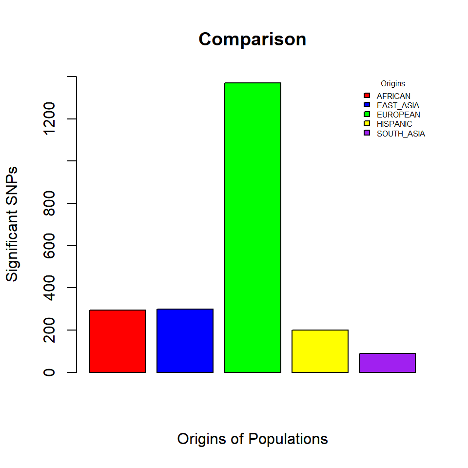

```r
#visual representation of the above data
pop<- c("AFRICAN" , "EAST_ASIA",  "EUROPEAN"  , "HISPANIC", "SOUTH_ASIA")

par(mfrow = c (1,1))
barplot(significant_snps_per_super_population, col = c("red", "blue", "green", "yellow", "purple"), xlab = "Origins of Populations",
        ylab = "Significant SNPs", xaxt = "n", ylim = c(0,1400),
        main = "Comparison")
legend("topright", legend = pop , fill = c("red", "blue", "green", "yellow", "purple"), title = "Origins", xjust = 1, yjust = 0, bty = "n", cex = 0.5)
```

### Answer - The total number of significant SNPs are 2253 with Europe having the highest - 1371, and South Asia having the lowest - 89.

## Europeans genetic variability can/cannot be found in other super populations

```r
#better understanding of the new subset of data
summary(significant_snps)
```

```
##     SNPID               RSID                CHR              POS
##  Length:2253        Length:2253        Min.   : 1.000   Min.   :   123233
##  Class :character   Class :character   1st Qu.: 3.000   1st Qu.: 34383788
##  Mode  :character   Mode  :character   Median : 7.000   Median : 70051966
##                                        Mean   : 8.295   Mean   : 79655840
##                                        3rd Qu.:12.000   3rd Qu.:114226535
##                                        Max.   :22.000   Max.   :247010734
##  EFFECT_ALLELE      OTHER_ALLELE       EFFECT_ALLELE_FREQ      BETA
##  Length:2253        Length:2253        Min.   :0.0105     Min.   :-0.397104
##  Class :character   Class :character   1st Qu.:0.1590     1st Qu.:-0.010464
##  Mode  :character   Mode  :character   Median :0.3350     Median :-0.003257
##                                        Mean   :0.3799     Mean   :-0.001079
##                                        3rd Qu.:0.5720     3rd Qu.: 0.009352
##                                        Max.   :1.0000     Max.   : 0.081540
##        SE                 P                   N             ANCESTRY
##  Min.   :0.001040   Min.   :0.000e+00   Min.   :  21912   Length:2253
##  1st Qu.:0.001170   1st Qu.:1.210e-07   1st Qu.: 107061   Class :character
##  Median :0.001790   Median :2.433e-04   Median :1573790   Mode  :character
##  Mean   :0.003465   Mean   :1.840e-03   Mean   :1007854
##  3rd Qu.:0.004810   3rd Qu.:2.841e-03   3rd Qu.:1593869
##  Max.   :0.137000   Max.   :9.997e-03   Max.   :1597373
```

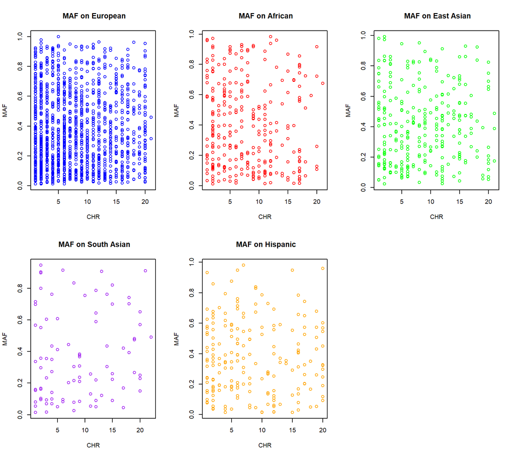

```r
#subsetting based on populations in the unfiltered dataset
african <- subset(sample, ANCESTRY == "AFRICAN")
european <- subset(sample, ANCESTRY == "EUROPEAN")
south_asia <- subset(sample, ANCESTRY == "SOUTH_ASIA")
east_asia <- subset(sample, ANCESTRY == "EAST_ASIA")
hispanic <- subset(sample, ANCESTRY == "HISPANIC")

#subsetting based on populations in the filtered dataset
sign_snps_african <- subset(significant_snps, ANCESTRY == "AFRICAN")
sign_snps_european <- subset(significant_snps, ANCESTRY == "EUROPEAN")
sign_snps_south_asia <- subset(significant_snps, ANCESTRY == "SOUTH_ASIA")
sign_snps_east_asia <- subset(significant_snps, ANCESTRY == "EAST_ASIA")
sign_snps_hispanic <- subset(significant_snps, ANCESTRY == "HISPANIC")

# remove europe alone
others_sign_snp <- significant_snps [significant_snps$ANCESTRY != "EUROPEAN", ]

# since european pop has highest number of filtered significant data (in human height), these plots shows how much MAF affects in all chromosomes across all the given populations.#

par(mfrow = c (2,3))

plot( sign_snps_european$CHR, sign_snps_european$EFFECT_ALLELE_FREQ, type = "p", col = "blue", xlab = "CHR", ylab = "MAF", main = " MAF on European")
plot( sign_snps_african$CHR, sign_snps_african$EFFECT_ALLELE_FREQ, type = "p", col = "red", xlab = "CHR", ylab = "MAF", main = " MAF on African")
plot( sign_snps_east_asia$CHR, sign_snps_east_asia$EFFECT_ALLELE_FREQ, type = "p", col = "green", xlab = "CHR", ylab = "MAF", main = " MAF on East Asian")
plot( sign_snps_south_asia$CHR, sign_snps_south_asia$EFFECT_ALLELE_FREQ, type = "p", col = "purple", xlab = "CHR", ylab = "MAF", main = " MAF on South Asian")
plot( sign_snps_hispanic$CHR, sign_snps_hispanic$EFFECT_ALLELE_FREQ, type = "p", col = "orange", xlab = "CHR", ylab = "MAF", main = " MAF on Hispanic")
```

## Relationship between BETA values and Chromosomes across all populations

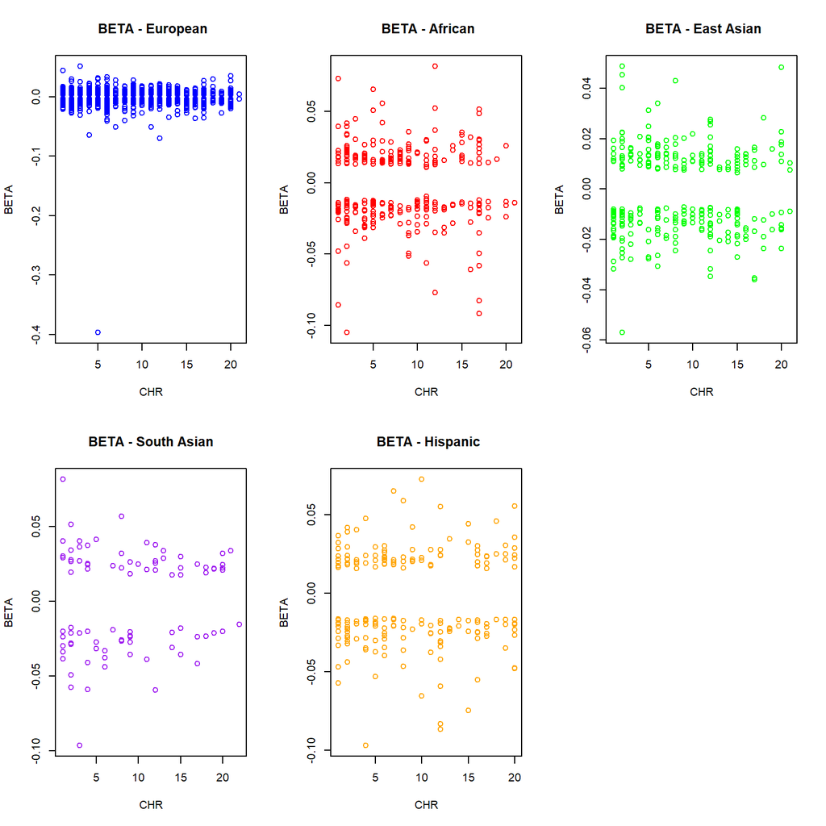

```r
par(mfrow = c (2,3))

plot( sign_snps_european$CHR, sign_snps_european$BETA, type = "p", col = "blue", xlab = "CHR", ylab = "BETA", main = " BETA - European")
plot( sign_snps_african$CHR, sign_snps_african$BETA, type = "p", col = "red", xlab = "CHR", ylab = "BETA", main = " BETA - African")
plot( sign_snps_east_asia$CHR, sign_snps_east_asia$BETA, type = "p", col = "green", xlab = "CHR", ylab = "BETA", main = " BETA - East Asian")
plot( sign_snps_south_asia$CHR, sign_snps_south_asia$BETA, type = "p", col = "purple", xlab = "CHR", ylab = "BETA", main = "BETA - South Asian")
plot( sign_snps_hispanic$CHR, sign_snps_hispanic$BETA, type = "p", col = "orange", xlab = "CHR", ylab = "BETA", main = " BETA - Hispanic")
```